# Lecture 5 Optional Appendix: While Loops

This is an optional note on how to use While Loops  
and list comprehensions

- Read this after the Lecture 5 file

## I. Import Libraries

```python
# the "numPy" library is used for mathematical operations
# the "matplotlib" library is for generating graphs
# the "pandas" library is for manipualting datasets

import matplotlib.pyplot as plt
```

## II. The while loop

- Used to iterate over a block of code as long as the test expression (condition) is true.
- Use when we don't know the number of times to iterate beforehand.

[figure not shown]

Continue to run code  
while a condition holds

```
while test_expression:
       Body
```

Example: More accuracy!

$f(x) = \frac{1}{x}$

- If $x$ is high enough, then $f(x)$ becomes very small
- We can continue to run values until $f(x) < e$
- Here the value $e$ is a threshold

Similar logic for any algorithm that needs more iterations for accuracy

```
[]
```

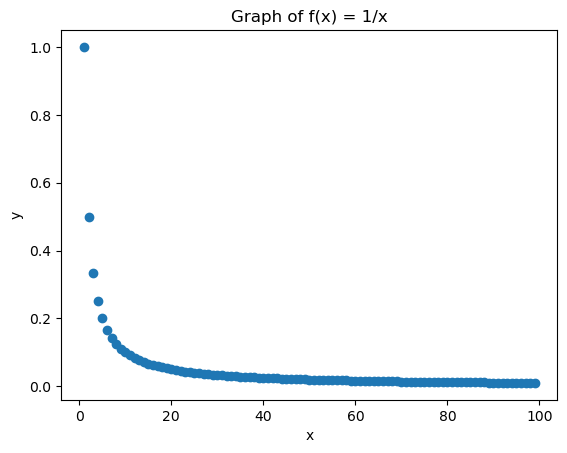

```python
# Specify a threshold level

e = 0.01

x_list = []
y_list = []

print(x_list)

x = 1
while 1/x > e:
    x_list.append(x)
    y_list.append(1/x)
    x = x + 1

plt.scatter(x= x_list, y = y_list)
plt.title("Graph of f(x) = 1/x")
plt.xlabel("x")
plt.ylabel("y")
```

Example: Finding candidates with a cutoff

```python
# This code loops over the list of players
# and stops once 2 tennis players are found


list_sports = ["tennis","golf","golf","tennis","golf","golf"]

candidate_list = []
num_candidates = 0

index = 0
while num_candidates < 2:
    print(index)
    if(list_sports[index] == "tennis"):
        candidate_list.append(index)
        num_candidates = num_candidates + 1

    index = index + 1

print(candidate_list)
```

```
0
1
2
3
[0, 3]
```

Try it yourself

- Solve the same problem with a "for" loop
- Use the option "break" to conclude iterations early

```python
# Write down your code here
```

## II. List Comprehensions

List Comprehension

- A one-line for loop
- Easy way to save the output to a list

```
list_name = [ expression for value in list_values]
```

```python
# Example 1: Customized Messages

id_list = ["KIA", "Ferrari", "Ford", "Tesla"]
message_list = ["Your car model is :" + id for id in id_list]

print(message_list)
```

```
['Your car model is :KIA', 'Your car model is :Ferrari', 'Your car model is :Ford', 'Your car model is :Tesla']
```

```python
# Example 2: Customized Message + Numering

topic_list   = ["Python", "Python","SQL"]
module_list  = ["One", "Two", "Three"]

num_topics = len(topic_list)

message_list = [" Module " + module_list[i] + " will cover " + topic_list[i] for i in range(num_topics)]
```

```python
# Example 3: Math operations
x_list = [ 1,2,3,4,5,6,7  ]

x_sqr_list = [ x**2 for x in x_list ]
```

## III. Interrupting for loops

Skipping iterations: Continue

- Combine it with if/else
- Useful for running loop for a subset of elements in list

```python
# The isinstance(value,int) function checks whether "value" is an integer.UserWarning
# The code will skip the remainder of any iteration when "continue' is called.

list_mixed = [1,2,"text_message",5]

for value in list_mixed:
    if(not isinstance(value,int)):
        continue
    print(value)
```

```
1
2
5
```

Stopping the loop: Breaking

```python
# In the same example as above, we can use "break" to stop the loop altogether

list_mixed = [1,2,"text_message",5]

for value in list_mixed:
    if(not isinstance(value,int)):
        print("Stopped: There is an element in your list that isn't an integer")
        break
    print(value)
```

```
1
2
Stopped: There is an element in your list that isn't an integer
```